# ReSpectR vs. Python: Direct Output Comparison

## Overview

This vignette computes fresh ReSpectR results **in-memory** (no file writes) and compares them directly against precomputed Python (`pyReSpect`) output files bundled in `inst/extdata`.

Three levels of comparison are performed per test:

1. **H(τ) spectrum** — point-by-point agreement of the continuous spectrum on the shared tau grid (identical algorithm ⟹ identical grid points).
2. **Fitted G values** — point-by-point agreement of G(t) (time) or G′/G″(ω) (frequency) produced by the continuous spectrum kernel reconstruction.
3. **Discrete modes** — comparison of Nopt and per-mode (τ, g) parameters.

Python reference files are in `inst/extdata/py_output_time/` and `inst/extdata/py_output_freq/`, one sub-directory per test case.

## Time-Domain Comparison

```r
time_tests <- paste0("test", 1:7)
time_dir   <- file.path(base, "time_tests")

time_results <- lapply(time_tests, function(tt) {
  dat_file  <- file.path(time_dir, paste0(tt, ".dat"))
  stopifnot(file.exists(dat_file))

  r   <- run_r_test("time", dat_file)
  py  <- read_py_output("time", tt, base)

  hc    <- compare_H(r$crs$s, r$crs$H, py$H)
  gfc   <- compare_Gfit("time", r$crs$Gfit, py$Gfit)

  # Discrete modes: Python time dmodes = (g, tau, dtau) — 3 columns
  py_Nopt  <- nrow(py$dmodes)
  # R modes sorted by tau for comparison
  r_modes  <- data.frame(tau = r$drs$tau, g = r$drs$g)
  r_modes  <- r_modes[order(r_modes$tau), ]
  py_modes <- data.frame(tau = py$dmodes$V2, g = py$dmodes$V1)
  py_modes <- py_modes[order(py_modes$tau), ]

  # lamC from summary reference
  lam_ref <- ref_H_time[ref_H_time$test == paste0(tt, ".dat"), ]

  list(
    test         = tt,
    tau          = hc$tau,
    H_R          = hc$H_R,
    H_PY         = hc$H_PY,
    lamC_R       = r$crs$lamC,
    lamC_PY      = if (nrow(lam_ref) > 0) lam_ref$lamC_PY else NA,
    Nopt_R       = r$drs$Nopt,
    Nopt_PY_file = py_Nopt,
    H_rmse       = hc$rmse,
    H_max_diff   = hc$max_diff,
    Gfit_rmse    = gfc$rmse,
    Gfit_rel     = gfc$rel_rmse,
    r_modes      = r_modes,
    py_modes     = py_modes
  )
})
```

### H(τ) Spectrum Agreement (Time)

RMSE and max |ΔH| are on the H-value scale (the same log-space units used internally by both solvers).

```r
time_H_tbl <- do.call(rbind, lapply(time_results, function(r)
  data.frame(
    test       = r$test,
    lamC_R     = round(r$lamC_R,  4),
    lamC_PY    = round(r$lamC_PY, 4),
    H_rmse     = signif(r$H_rmse,     3),
    H_max_diff = signif(r$H_max_diff, 3)
  )))
time_H_tbl
```

```
#>    test lamC_R lamC_PY   H_rmse H_max_diff
#> 1 test1 0.4989      NA 7.10e-03   1.94e-02
#> 2 test2 2.1884      NA 8.11e-04   3.29e-03
#> 3 test3 3.1572      NA 2.14e-05   8.45e-05
#> 4 test4 2.6660      NA 1.89e-04   8.51e-04
#> 5 test5 1.4240      NA 6.13e-04   1.49e-03
#> 6 test6 3.3813      NA 8.80e-06   2.90e-05
#> 7 test7 2.9746      NA 2.07e-05   6.18e-05
```

### Fitted G(t) Agreement (Time)

```r
time_Gfit_tbl <- do.call(rbind, lapply(time_results, function(r)
  data.frame(
    test        = r$test,
    Gfit_rmse   = signif(r$Gfit_rmse, 3),
    Gfit_rel    = signif(r$Gfit_rel,  3)
  )))
time_Gfit_tbl
```

```
#>    test Gfit_rmse Gfit_rel
#> 1 test1  5.30e-06 1.99e-05
#> 2 test2  5.33e-06 1.67e-06
#> 3 test3  4.87e-05 2.52e-07
#> 4 test4  1.45e-06 2.50e-06
#> 5 test5  1.27e-06 1.91e-06
#> 6 test6  4.76e-01 6.68e-07
#> 7 test7  1.59e-04 6.96e-07
```

### Discrete Modes (Time)

`Nopt_R` is the count returned by `getDiscreteSpectrum()`. `Nopt_PY_file` counts rows in the Python `dmodes.dat` — Python omits modes that collapsed to the grid boundary during refinement, so this can be slightly lower than the declared optimal Nopt.

```r
time_modes_tbl <- do.call(rbind, lapply(time_results, function(r)
  data.frame(
    test         = r$test,
    Nopt_R       = r$Nopt_R,
    Nopt_PY_file = r$Nopt_PY_file
  )))
time_modes_tbl
```

```
#>    test Nopt_R Nopt_PY_file
#> 1 test1      5            2
#> 2 test2      7            5
#> 3 test3     11           10
#> 4 test4      8            8
#> 5 test5      5            5
#> 6 test6      8            8
#> 7 test7      9            8
```

Per-mode detail (τ, g) for the first two time tests:

```r
for (i in 1:2) {
  res <- time_results[[i]]
  tbl <- side_by_side_modes(res$r_modes, res$py_modes)
  cat(sprintf("\n**%s — Side-by-side discrete modes:**\n\n", res$test))
  print(knitr::kable(round(tbl, 5), digits = 5,
                     col.names = c("tau_R", "g_R", "tau_PY", "g_PY")))
}
```

**test1 — Side-by-side discrete modes:**

| tau_R | g_R | tau_PY | g_PY |
| --- | --- | --- | --- |
| 4.84989 | 1.14700 | 4.84987 | 1.14700 |
| 49.87199 | 0.50281 | 49.87198 | 0.50281 |

**test2 — Side-by-side discrete modes:**

| tau_R | g_R | tau_PY | g_PY |
| --- | --- | --- | --- |
| 0.05 | 1 | 0.05000 | 1 |
| 0.50 | 1 | 0.50000 | 1 |
| 5.00 | 1 | 5.00000 | 1 |
| 50.00 | 1 | 49.99998 | 1 |
| NA | NA | 186.38960 | 0 |

### H(τ) Overlay Plot (Time)

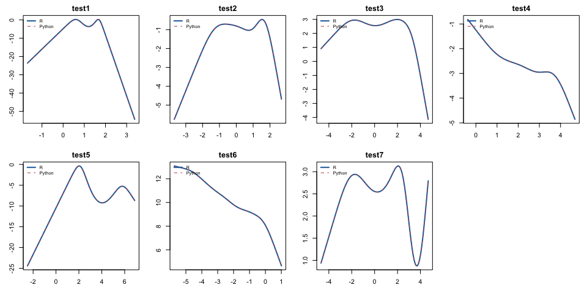

```r
op <- par(mfrow = c(2, 4), mar = c(3, 3, 2, 1))
for (res in time_results) {
  plot(log10(res$tau), res$H_R, type = "l",
    col = "#1b6ca8", lwd = 2,
    main = res$test, xlab = "log10(τ)", ylab = "H")
  lines(log10(res$tau), res$H_PY, col = "#c44e52", lwd = 1, lty = 2)
  legend("topleft", c("R", "Python"), col = c("#1b6ca8", "#c44e52"),
         lwd = c(2, 1), lty = c(1, 2), bty = "n", cex = 0.7)
}
par(op)
```

## Frequency-Domain Comparison

```r
freq_tests <- c("test1", "test1n", "test1u", "test2", "test3",
                "test4", "test5", "test6", "test7")
freq_dir   <- file.path(base, "freq_tests")

freq_results <- lapply(freq_tests, function(tt) {
  dat_file <- file.path(freq_dir, paste0(tt, ".dat"))
  stopifnot(file.exists(dat_file))

  r  <- run_r_test("frequency", dat_file, plateau = tt %in% plateau_tests)
  py <- read_py_output("frequency", tt, base)

  hc  <- compare_H(r$crs$s, r$crs$H, py$H)
  gfc <- compare_Gfit("frequency", r$crs$Gfit, py$Gfit)

  # Discrete modes: Python freq dmodes = (g, tau) — 2 columns
  py_Nopt  <- nrow(py$dmodes)
  r_modes  <- data.frame(tau = r$drs$tau, g = r$drs$g)
  r_modes  <- r_modes[order(r_modes$tau), ]
  py_modes <- data.frame(tau = py$dmodes$V2, g = py$dmodes$V1)
  py_modes <- py_modes[order(py_modes$tau), ]

  lam_ref <- ref_H_freq[ref_H_freq$test == paste0(tt, ".dat"), ]

  list(
    test         = tt,
    lamC_R       = r$crs$lamC,
    lamC_PY      = if (nrow(lam_ref) > 0) lam_ref$lamC_PY else NA,
    Nopt_R       = r$drs$Nopt,
    Nopt_PY_file = py_Nopt,
    H_rmse       = hc$rmse,
    H_max_diff   = hc$max_diff,
    Gfit_rmse    = gfc$rmse,
    Gfit_rel     = gfc$rel_rmse,
    r_modes      = r_modes,
    py_modes     = py_modes
  )
})
```

```
#> G0 = -2.382e-03
#> G0 = 7.429e+02
```

### H(τ) Spectrum Agreement (Frequency)

For the frequency domain the H vector stores the spectral amplitude on the same shared τ grid; the third column of `H.dat` is zero (imaginary part is not used).

```r
freq_H_tbl <- do.call(rbind, lapply(freq_results, function(r)
  data.frame(
    test       = r$test,
    lamC_R     = round(r$lamC_R,  4),
    lamC_PY    = round(r$lamC_PY, 4),
    H_rmse     = signif(r$H_rmse,     3),
    H_max_diff = signif(r$H_max_diff, 3)
  )))
freq_H_tbl
```

```
#>     test lamC_R lamC_PY   H_rmse H_max_diff
#> 1  test1 4.2838      NA 2.70e-07   4.90e-07
#> 2 test1n 4.3177      NA 2.91e-07   4.98e-07
#> 3 test1u 4.1652      NA 2.79e-07   4.99e-07
#> 4  test2 3.1788      NA 6.45e-06   2.62e-05
#> 5  test3 3.6724      NA 1.88e-06   4.93e-06
#> 6  test4 4.6490      NA 2.24e-06   4.94e-06
#> 7  test5 6.6744      NA 1.04e-05   6.81e-05
#> 8  test6 3.0871      NA 4.83e-04   1.53e-03
#> 9  test7 3.3437      NA 2.83e-07   4.97e-07
```

### Fitted G*(ω) Agreement (Frequency)

```r
freq_Gfit_tbl <- do.call(rbind, lapply(freq_results, function(r)
  data.frame(
    test      = r$test,
    Gfit_rmse = signif(r$Gfit_rmse, 3),
    Gfit_rel  = signif(r$Gfit_rel,  3)
  )))
freq_Gfit_tbl
```

```
#>     test Gfit_rmse Gfit_rel
#> 1  test1  2.33e-05 1.60e-07
#> 2 test1n  2.29e-05 1.63e-07
#> 3 test1u  2.08e-04 1.00e-07
#> 4  test2  3.65e-08 1.46e-07
#> 5  test3  2.16e-02 1.39e-07
#> 6  test4  1.03e-01 1.33e-07
#> 7  test5  1.87e+02 8.46e-06
#> 8  test6  5.87e-06 7.56e-06
#> 9  test7  2.84e-05 3.14e-08
```

### Discrete Modes (Frequency)

```r
freq_modes_tbl <- do.call(rbind, lapply(freq_results, function(r)
  data.frame(
    test         = r$test,
    Nopt_R       = r$Nopt_R,
    Nopt_PY_file = r$Nopt_PY_file
  )))
freq_modes_tbl
```

```
#>     test Nopt_R Nopt_PY_file
#> 1  test1     15           14
#> 2 test1n     13           13
#> 3 test1u     16           16
#> 4  test2     10            8
#> 5  test3     10           13
#> 6  test4     13           12
#> 7  test5     18           17
#> 8  test6      7            6
#> 9  test7      7            7
```

Per-mode detail for test1 frequency:

```r
res <- freq_results[[1]]
tbl <- side_by_side_modes(res$r_modes, res$py_modes)
cat("\n**test1 (frequency) — Side-by-side discrete modes:**\n\n")
```

**test1 (frequency) — Side-by-side discrete modes:**

```r
print(knitr::kable(round(tbl, 5), digits = 5,
                   col.names = c("tau_R", "g_R", "tau_PY", "g_PY")))
```

| tau_R | g_R | tau_PY | g_PY |
| --- | --- | --- | --- |
| 0.00028 | 3.80684 | 0.00025 | 2.99102 |
| 0.00117 | 15.26648 | 0.00095 | 12.43104 |
| 0.00461 | 26.13635 | 0.00345 | 22.92401 |
| 0.01873 | 27.79279 | 0.01265 | 26.33987 |
| 0.07981 | 23.75559 | 0.04819 | 23.60627 |
| 0.35460 | 20.15830 | 0.19066 | 19.85988 |
| 1.60487 | 19.52039 | 0.77254 | 18.04206 |
| 7.18160 | 22.06456 | 3.13904 | 18.87121 |
| 30.85047 | 26.25231 | 12.50127 | 22.00147 |
| 124.57059 | 27.22551 | 47.79915 | 25.41070 |
| 470.76913 | 19.77245 | 173.26660 | 24.58262 |
| 1698.45342 | 8.01044 | 595.77540 | 16.57071 |
| 6411.16937 | 1.32108 | 1983.95800 | 6.40616 |
| NA | NA | 7017.85400 | 1.06121 |

## Aggregate Summary

```r
agg_time <- data.frame(
  domain         = "time",
  mean_H_rmse    = mean(sapply(time_results,  `[[`, "H_rmse")),
  max_H_rmse     = max(sapply(time_results,   `[[`, "H_rmse")),
  mean_Gfit_rmse = mean(sapply(time_results,  `[[`, "Gfit_rmse")),
  mean_Nopt_diff = mean(abs(sapply(time_results,  `[[`, "Nopt_R") -
                            sapply(time_results,  `[[`, "Nopt_PY_file")))
)
agg_freq <- data.frame(
  domain         = "frequency",
  mean_H_rmse    = mean(sapply(freq_results,  `[[`, "H_rmse")),
  max_H_rmse     = max(sapply(freq_results,   `[[`, "H_rmse")),
  mean_Gfit_rmse = mean(sapply(freq_results,  `[[`, "Gfit_rmse")),
  mean_Nopt_diff = mean(abs(sapply(freq_results,  `[[`, "Nopt_R") -
                            sapply(freq_results,  `[[`, "Nopt_PY_file")))
)
rbind(agg_time, agg_freq)
```

```
#>      domain  mean_H_rmse   max_H_rmse mean_Gfit_rmse mean_Nopt_diff
#> 1      time 1.251497e-03 0.0070977151     0.06805753              1
#> 2 frequency 5.617025e-05 0.0004834761    20.80118285              1
```

## Notes

- All R results are computed fresh in-memory (`writeOutput = FALSE`).
- Python output files (`H.dat`, `Gfit.dat`, `dmodes.dat`) were precomputed with the original `pyReSpect` code and are bundled in `inst/extdata/py_output_time/` and `inst/extdata/py_output_freq/`.
- Python and R use an identical tau grid formula: both generate `ns = 100` points geometrically spaced between the same `smin` and `smax` derived from the data, so H(τ) can be compared point-by-point without interpolation.
- `lamC_PY` values come from the packaged summary CSVs (`comparison_H_*.csv`) rather than from the individual output files, since the Python code selects the optimal λ during the L-curve search rather than writing it in a parseable scalar form.
- `Nopt_PY_file` counts rows in Python’s `dmodes.dat`. Python omits modes that collapsed to grid boundaries during optimisation, so this number can differ from R’s `Nopt` without indicating a real algorithmic discrepancy.